# HW 10 - advMCMC

Shuang Du (PID: 730424618)

# MCMC extension of HW 6

We would like to simulate from the posterior distribution of parameter $\boldsymbol{\theta} = (\pi,\lambda)$ pertaining to the fishing dataset and zero-inflated poisson model described in HW 6, assuming $\pi$ has a Unif(0,1) prior, and $\lambda$ has a Gamma(2,2) prior (shape and scale = 2). The joint posterior can be written as $f(\pi,\lambda | \boldsymbol{y}) \propto f(\boldsymbol{y} | \pi, \lambda)f(\pi,\lambda) = f(\boldsymbol{y} | \pi, \lambda)f(\pi)f(\lambda)$, where $f(\boldsymbol{y} | \pi,\lambda)$ is the likelihood give in HW 6 except with $\lambda$ unknown, $f(\pi)$ is the specified prior for $\pi$, and $f(\lambda)$ is the specified prior for $\lambda$.

Implement a MH random walk procedure to sample from the joint posterior of $\boldsymbol{\theta} = (\pi,\lambda)$. You do not necessarily need to do a change of variable for $\pi$ or $\lambda$, however for proposals that exceed the boundaries of the parameter space of either parameter, the posterior for the propsal should be set = 0 (MH ratio = 0). You may want to consider a narrower random walk variance in such as setting as well.

```r
### HELPER FUNCTIONS
# log prior for lambda, fill in
lplambda = function(lambda){
  return(log(dgamma(lambda, shape = 2, rate = 0.5)))
}

# log prior for pi, fill in
lppi = function(pi){
  return(log(dunif(pi, 0, 1)))
}

# bivariate RW proposal function
# hint: bivariate proposal same as generating two indep proposals here
h.sim = function(){
  return(runif(2,-0.06,0.06))
}

# returns ll, or log f(y|lambda, pi)
# compute given y and ny from table
ll = function(y, ny, x){
  pi = x[1]
  lambda = x[2]
  ll = ny[1]*log(pi[1]+(1-pi[1])*exp(-lambda)) +(sum(ny)-ny[1])*(log(1-pi[1]) - lambda) + sum(ny*y)*log(lambda) + lplambda(lambda) + lppi(pi)
  return(ll)
}

# MH ratio
# Hint; since h symmetric, proposal density cancels out of ratio
R = function(y, y_weight, x, xt){
  # x is the proposal, xt is current state
  # x[1],xt[1] pertain to pi, x[2],xt[2] pertain to lambda
  logR <- ll(y, y_weight, x) - ll(y, y_weight, xt)
  R = exp(logR)
  return(R)
}
```

Now start the main code for the sample:

```r
# set the seed
set.seed(1)
# data fro HW 6
y = 0:6
ny = c(3062, 587, 284, 103, 33, 4, 2)
# Set chain length
M = 20000
# initialize the chain vector (alpha, lambda)
x.rw.chain = matrix(0, M, 2)
colnames(x.rw.chain) = c("pi","lambda")
# Initialize chain with specified initial values
# alpha, lambda
x.rw.chain[1,] = c(0.3, 3)

# now start chain
for(i in 1:(M-1)){
  # set the value at current iteration of the chain to variable xt
  xt = x.rw.chain[i,]
  # draw a proposal from the proposal density
  x = xt + h.sim()
  # calculate MH ratio
  if((x[1]>0)&(x[1]<1)&(x[2]>0)){
    r = min(R(y, ny, x, xt), 1)
  } else{
    r=0
  }
  # Generate draw from bernoulli(p).
  keep = rbinom(1, 1, r)
  # if keep = 1, then set next iteration equal to then proposal
  if(keep == 1){
    x.rw.chain[i+1,] = x
  }else{
    # otherwise, carry over value from the current iteration
    x.rw.chain[i+1,] = xt
  }
}
```

Here are the posterior means for $\pi$ and $\lambda$ :

```r
burn.in = 500
# posterior mean for pi
mean(x.rw.chain[-c(1:burn.in), 1])
```

```
## [1] 0.6145888
```

```r
# posterior mean for lambda
mean(x.rw.chain[-c(1:burn.in), 2])
```

```
## [1] 1.037937
```

diagnostic plots for $\pi$ :

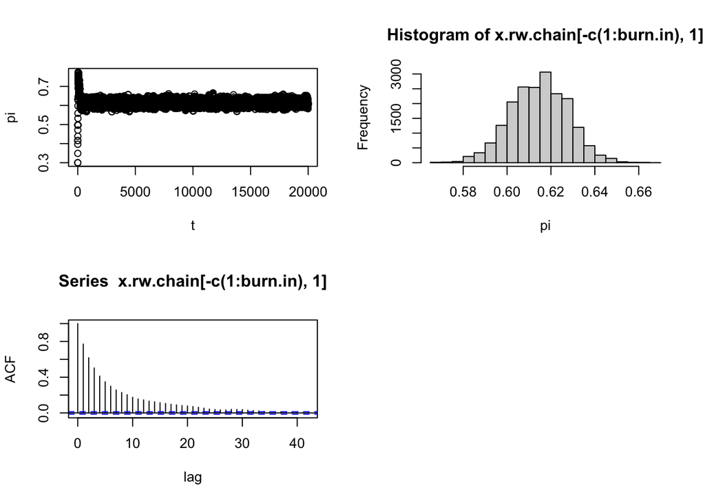

```r
# Diagnostics for pi
par(mfrow=c(2,2))
plot(x.rw.chain[, 1],ylab="pi",xlab="t")
hist(x.rw.chain[-c(1:burn.in), 1],breaks=20,xlab="pi")
acf(x.rw.chain[-c(1:burn.in), 1], ylab="ACF",xlab="lag")
```

diagnostic plots for $\lambda$ :

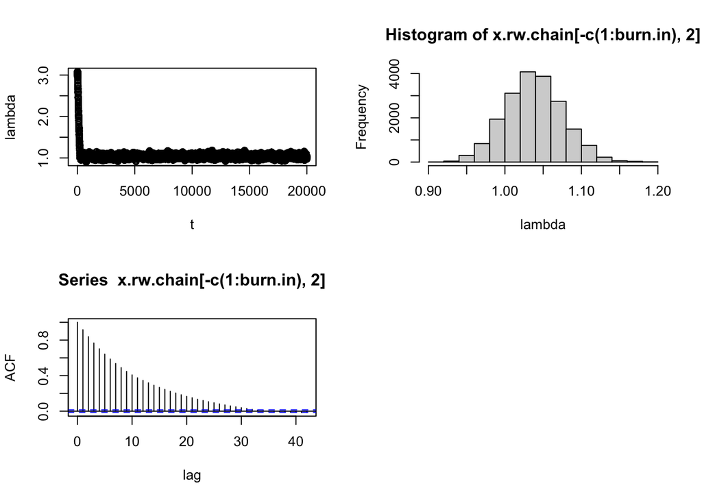

```r
# Diagnostics for lambda
par(mfrow=c(2,2))
plot(x.rw.chain[, 2],ylab="lambda",xlab="t")
hist(x.rw.chain[-c(1:burn.in), 2],breaks=20,xlab="lambda")
acf(x.rw.chain[-c(1:burn.in), 2], ylab="ACF",xlab="lag")
```